# Part 4 — Tuning, benchmarking, calibration and thresholds

Complete tutorial for sciModelFlowR (version 1.0.2)

Author

Walter Esfrain Pereira

Published

September 19, 2026

# 1 Hyperparameter tuning without optimism

Two different questions: **which configuration** of the same model is better (tuning) and **which model** is better (benchmarking). The package separates the two and requires the decision criterion to be explicit — including in multi-objective cases.

```r
field <- ler("field_yield")
v <- verdade$field_yield
no_out <- field[!field$plot_id %in% v$outlier_ids, ]

spec_xgb <- smf_experiment_spec(
  task = smf_task_spec("regression", "yield"),
  data = smf_data_spec("yield", c("nitrogen", "potassium", "water", "organic_matter",
                                  "block", "genotype"),
                       id_column = "plot_id", categorical = c("block", "genotype")),
  design = smf_design_spec(id_column = "plot_id"),
  preprocessing = smf_preprocess_spec("median"),
  model = smf_model_spec("boosted_tree", "xgboost",
                         parameters = list(nrounds = 60L, params = list(max_depth = 3L))),
  metrics = list(smf_metric_spec("rmse", "minimize"), smf_metric_spec("mae", "minimize")),
  reproducibility = smf_reproducibility_spec(61L)
)
space <- smf_search_space(nrounds = smf_param_int(30L, 90L),
                          params.max_depth = smf_param_int(2L, 6L))
print(space)
```

```
<sciModelFlowR::SearchSpace>
 @ parameters:List of 2
 .. $ nrounds         :List of 7
 ..  ..$ type      : chr "int"
 ..  ..$ lower     : int 30
 ..  ..$ upper     : int 90
 ..  ..$ values    : NULL
 ..  ..$ log       : logi FALSE
 ..  ..$ depends_on: NULL
 ..  ..$ resource  : logi FALSE
 .. $ params.max_depth:List of 7
 ..  ..$ type      : chr "int"
 ..  ..$ lower     : int 2
 ..  ..$ upper     : int 6
 ..  ..$ values    : NULL
 ..  ..$ log       : logi FALSE
 ..  ..$ depends_on: NULL
 ..  ..$ resource  : logi FALSE
 @ conditions:List of 2
 .. $ nrounds         : NULL
 .. $ params.max_depth: NULL
 @ metadata  : list()
```

```r
t_grid <- smf_tune(spec_xgb, no_out, space, smf_tuning_spec("grid", budget = 4L,
  inner_resampling = smf_resampling_spec("kfold", n_splits = 3L, seed = 61L),
  objectives = list(smf_metric_spec("rmse", "minimize")), seed = 61L))
t_rand <- smf_tune(spec_xgb, no_out, space, smf_tuning_spec("random", budget = 6L,
  inner_resampling = smf_resampling_spec("kfold", n_splits = 3L, seed = 62L),
  objectives = list(smf_metric_spec("rmse", "minimize"), smf_metric_spec("mae", "minimize")),
  decision_rule = list(type = "weighted_sum", weights = c(rmse = 0.7, mae = 0.3)),
  seed = 62L))
t_race <- smf_tune(spec_xgb, no_out, space, smf_tuning_spec("racing", budget = 6L,
  inner_resampling = smf_resampling_spec("kfold", n_splits = 4L, seed = 63L),
  objectives = list(smf_metric_spec("rmse", "minimize")), seed = 63L,
  parameters = list(min_folds = 2L)))
t_bayes <- smf_tune(spec_xgb, no_out, space, smf_tuning_spec("bayesian", budget = 6L,
  inner_resampling = smf_resampling_spec("kfold", n_splits = 3L, seed = 64L),
  objectives = list(smf_metric_spec("rmse", "minimize")), seed = 64L,
  parameters = list(initial = 3L, candidate_pool = 16L)))

method_tbl <- data.frame(
  method = c("grid", "random", "racing", "bayesian"),
  evaluations = c(nrow(t_grid@archive), nrow(t_rand@archive),
                  nrow(t_race@archive), nrow(t_bayes@archive)),
  best_rmse = c(min(t_grid@archive$rmse, na.rm = TRUE),
                min(t_rand@archive$rmse, na.rm = TRUE),
                min(t_race@archive$rmse, na.rm = TRUE),
                min(t_bayes@archive$rmse, na.rm = TRUE))
)
tab_smf(method_tbl, caption = "Four search strategies in the same space and with the same inner-fold budget.")
```

| method | evaluations | best_rmse |
| --- | --- | --- |
| grid | 4 | 457.446 |
| random | 6 | 435.995 |
| racing | 30 | 287.351 |
| bayesian | 6 | 453.169 |

```r
rand_tbl <- t_rand@archive[, c("trial", "nrounds", "params.max_depth", "rmse", "mae")]
sel_tbl <- t_rand@selected[, c("nrounds", "params.max_depth", "rmse", "mae")]
tab_smf(rand_tbl, caption = "Random-search archive: each row is a configuration evaluated on the inner resample.")
```

Random-search archive: each row is a configuration evaluated on the inner resample.

| trial | nrounds | params.max_depth | rmse | mae |
| --- | --- | --- | --- | --- |
| 1 | 57 | 4 | 450.784 | 350.966 |
| 2 | 34 | 6 | 466.550 | 364.083 |
| 3 | 59 | 6 | 466.766 | 364.138 |
| 4 | 82 | 5 | 477.875 | 364.123 |
| 5 | 33 | 2 | 435.995 | 330.821 |
| 6 | 36 | 6 | 466.505 | 364.089 |

```r
tab_smf(sel_tbl, caption = "Selected by the declared compromise rule (weights 0.7 for RMSE and 0.3 for MAE).")
```

Selected by the declared compromise rule (weights 0.7 for RMSE and 0.3 for MAE).

|  | nrounds | params.max_depth | rmse | mae |
| --- | --- | --- | --- | --- |
| 5 | 33 | 2 | 435.995 | 330.821 |

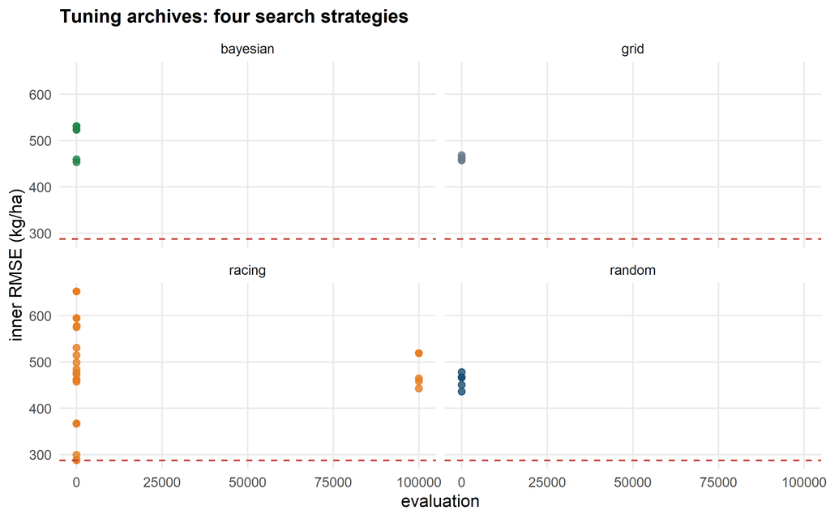

Figure 1: The full archive: each point is a configuration; the dashed line marks the best inner mean. Racing eliminates candidates fold by fold.

```r
archives <- rbind(
  data.frame(method = "grid", trial = t_grid@archive$trial, rmse = t_grid@archive$rmse),
  data.frame(method = "random", trial = t_rand@archive$trial, rmse = t_rand@archive$rmse),
  data.frame(method = "racing", trial = t_race@archive$trial, rmse = t_race@archive$rmse),
  data.frame(method = "bayesian", trial = t_bayes@archive$trial, rmse = t_bayes@archive$rmse)
)
ggplot(archives, aes(trial, rmse, colour = method)) +
  geom_point(size = 2, alpha = .8) +
  geom_hline(yintercept = min(archives$rmse, na.rm = TRUE), linetype = "dashed",
             colour = cores_smf[["alerta"]]) +
  facet_wrap(~method, nrow = 2) +
  scale_colour_manual(values = c(grid = cores_smf[["neutro"]], random = cores_smf[["primaria"]],
                                 racing = cores_smf[["destaque"]], bayesian = cores_smf[["sucesso"]]),
                      guide = "none") +
  labs(x = "evaluation", y = "inner RMSE (kg/ha)",
       title = "Tuning archives: four search strategies")
```

**WarningTrap**

An objective that is **not** in `spec@metrics` does not produce an empty archive: it aborts with a clear error (`TUNING_OBJECTIVE_NOT_IN_METRICS`), listing the available metrics. This behaviour is the 1.0.2 fix for a defect that returned an empty selection in silence. The package prefers to fail loudly.

**NoteInterpretation**

The best inner RMSE across all methods is 287.4 kg/ha, found by racing. Inner values are **not** the final performance: they choose the configuration. The honest estimate of the chosen one comes from an outer resample (here, the Part 3 holdout; at the limit, nested tuning).

# 2 Benchmarking: comparing models with a declared criterion

The benchmark evaluates several **models** in the same design, with repetitions and computational cost measures. The decision comes from an explicit rule.

```r
candidates <- list(
  lm = smf_model_spec("linear_regression", "stats"),
  rf = smf_model_spec("random_forest", "tidymodels",
                      parameters = list(model_engine = "ranger")),
  xgb = smf_model_spec("boosted_tree", "xgboost", parameters = list(nrounds = 60L))
)
bench <- smf_benchmark(spec_xgb, no_out, smf_benchmark_spec(
  candidates = candidates,
  metrics = list(smf_metric_spec("rmse", "minimize")),
  resampling = smf_resampling_spec("kfold", n_splits = 5L, seed = 71L),
  compute_measures = c("fit_time", "total_time"),
  repetitions = 2L, seed = 71L
))
tab_smf(bench@summary, caption = "Benchmark with 5 folds repeated twice: mean, SD, standard error and interval per candidate.")
```

Benchmark with 5 folds repeated twice: mean, SD, standard error and interval per candidate.

| candidate | metric | mean | sd | se | lower | upper | n |
| --- | --- | --- | --- | --- | --- | --- | --- |
| lm | rmse | 373.236 | 138.221 | 43.709 | 274.358 | 472.113 | 10 |
| rf | rmse | 584.586 | 82.826 | 26.192 | 525.336 | 643.836 | 10 |
| xgb | rmse | 497.491 | 75.344 | 23.826 | 443.594 | 551.389 | 10 |

```r
dec <- smf_decide_benchmark(bench, list(type = "weighted_sum", weights = c(rmse = 1)))
tab_smf(dec, caption = "Decision by the declared rule (weight 1 for RMSE).")
```

Decision by the declared rule (weight 1 for RMSE).

| candidate | rmse | .decision_score |
| --- | --- | --- |
| lm | 373.236 | 0 |

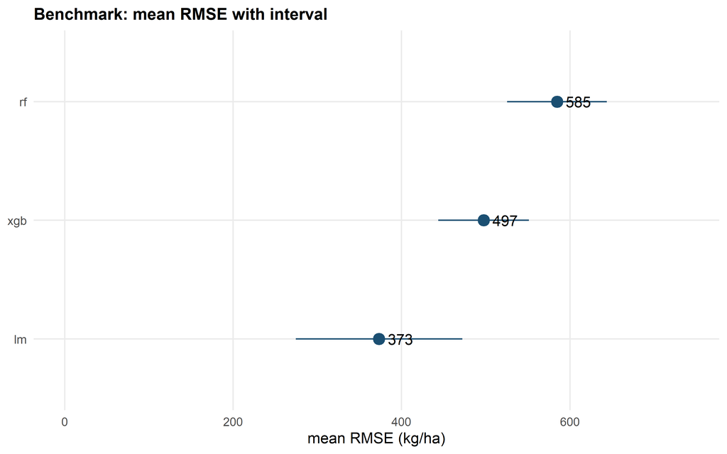

Figure 2: Mean performance with confidence interval per candidate: the straight line beats the flexible alternatives on this linear problem.

```r
ggplot(bench@summary, aes(stats::reorder(candidate, mean), mean)) +
  geom_pointrange(aes(ymin = lower, ymax = upper), colour = cores_smf[["primaria"]], size = .8) +
  geom_text(aes(label = fmt(mean, 0)), hjust = -0.35) +
  coord_flip() +
  labs(x = NULL, y = "mean RMSE (kg/ha)",
       title = "Benchmark: mean RMSE with interval") +
  ylim(0, max(bench@summary$upper) * 1.15)
```

**NoteInterpretation**

The winner by the rule is lm, with mean RMSE 373.2. The intervals overlap in part, but the conclusion does not depend on a single fold: it comes from 10 evaluations (5 folds x 2 repetitions) and from a rule declared before looking at the result.

# 3 Calibration: does the number mean what it promises?

A probability of 0.3 should correspond to ~30% of events. In the disease dataset, with label noise, that rarely happens without calibration. The package offers the calibrator (`smf_calibrate()`), the application (`smf_apply_calibration()`) and the report (`smf_calibration_report()`).

```r
disease <- ler("disease_binary")
disease$disease <- factor(disease$disease, levels = c(0, 1))
set.seed(20260919)
idx <- sample.int(nrow(disease))
i_te <- idx[1:100]
i_rest <- idx[101:nrow(disease)]
i_cal <- i_rest[1:120]
i_tr <- setdiff(i_rest, i_cal)
glm_p4 <- stats::glm(disease ~ x1 + x2 + x3 + x4, data = disease[i_tr, ],
                     family = stats::binomial())
p_cal_tr <- stats::predict(glm_p4, disease[i_cal, ], type = "response")
p_te <- stats::predict(glm_p4, disease[i_te, ], type = "response")
P_te <- cbind(`0` = 1 - p_te, `1` = p_te)
cal_p4 <- smf_calibrate(disease$disease[i_cal],
                        cbind(`0` = 1 - p_cal_tr, `1` = p_cal_tr),
                        smf_calibration_spec("platt"))
P_te_cal <- smf_apply_calibration(cal_p4, P_te)
rel_raw <- smf_calibration_report(disease$disease[i_te], P_te, bins = 5L,
                                  positive_label = "1")
rel_cal <- smf_calibration_report(disease$disease[i_te], P_te_cal, bins = 5L,
                                  positive_label = "1")
cal_tbl <- data.frame(
  measure = c("ECE", "log loss", "Brier"),
  raw = c(rel_raw$ece, rel_raw$log_loss, rel_raw$brier),
  calibrated = c(rel_cal$ece, rel_cal$log_loss, rel_cal$brier)
)
tab_smf(cal_tbl, caption = "Same test set, same logistic regression: before and after Platt calibration (calibration partition: 120 rows).")
```

Same test set, same logistic regression: before and after Platt calibration (calibration partition: 120 rows).

| measure | raw | calibrated |
| --- | --- | --- |
| ECE | 0.057 | 0.049 |
| log loss | 0.424 | 0.419 |
| Brier | 0.236 | 0.235 |

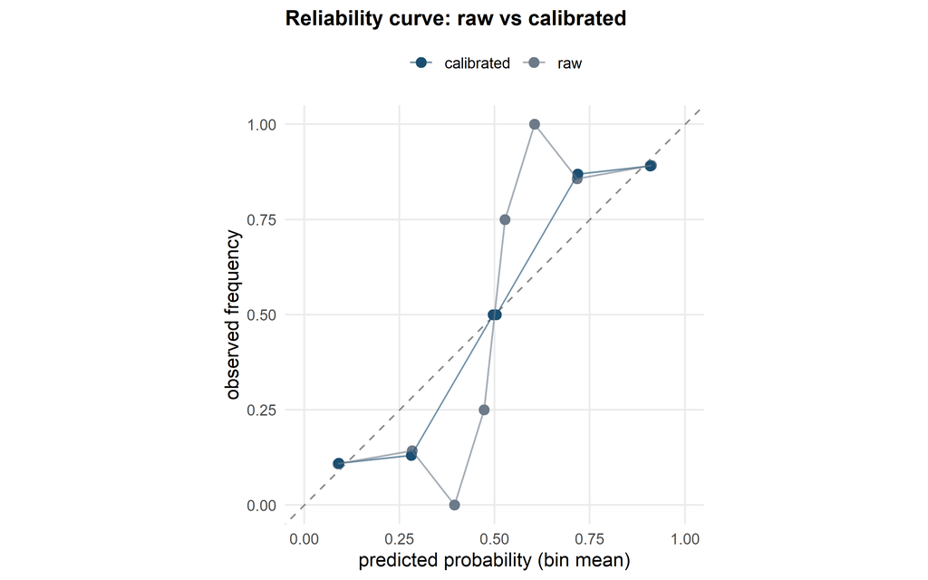

Figure 3: Reliability curve: predicted probability against observed frequency. The diagonal is perfect calibration.

```r
conf_raw <- rel_raw$table
conf_raw <- data.frame(predicted = conf_raw$mean_probability,
                       observed = conf_raw$observed_frequency,
                       version = "raw")
conf_cal <- rel_cal$table
conf_cal <- data.frame(predicted = conf_cal$mean_probability,
                       observed = conf_cal$observed_frequency,
                       version = "calibrated")
ggplot(rbind(conf_raw, conf_cal), aes(predicted, observed, colour = version)) +
  geom_abline(slope = 1, intercept = 0, linetype = "dashed", colour = "grey55") +
  geom_point(size = 2.6) +
  geom_line(alpha = .6) +
  scale_colour_manual(values = c(raw = cores_smf[["neutro"]],
                                 calibrated = cores_smf[["primaria"]])) +
  coord_equal(xlim = c(0, 1), ylim = c(0, 1)) +
  labs(x = "predicted probability (bin mean)", y = "observed frequency",
       colour = NULL,
       title = "Reliability curve: raw vs calibrated") +
  theme(legend.position = "top")
```

**ImportantInterpretation**

In this partition, raw ECE is 0.0571 and calibrated ECE is 0.0486. Calibrating is **not** automatically better: with only 120 calibration rows, the Platt calibrator can worsen ECE — the effect depends on the partition size and on noise. The rate below measures the procedure with repetition, which is the only evidence that decides.

```r
one_replicate_cal <- function(s, n_cal) {
  set.seed(s)
  n <- nrow(disease); order_idx <- sample.int(n)
  i_te_r <- order_idx[1:100]
  rest <- order_idx[101:n]
  i_cal_r <- rest[1:n_cal]
  i_tr_r <- setdiff(rest, i_cal_r)
  f <- stats::glm(disease ~ x1 + x2 + x3 + x4, data = disease[i_tr_r, ],
                  family = stats::binomial())
  p_c <- stats::predict(f, disease[i_cal_r, ], type = "response")
  p_t <- stats::predict(f, disease[i_te_r, ], type = "response")
  Pc <- cbind(`0` = 1 - p_c, `1` = p_c)
  Pt <- cbind(`0` = 1 - p_t, `1` = p_t)
  cr <- smf_calibrate(disease$disease[i_cal_r], Pc, smf_calibration_spec("platt"))
  Ptc <- smf_apply_calibration(cr, Pt)
  r0 <- smf_calibration_report(disease$disease[i_te_r], Pt, bins = 5L, positive_label = "1")
  r1 <- smf_calibration_report(disease$disease[i_te_r], Ptc, bins = 5L, positive_label = "1")
  c(ece_raw = r0$ece, ece_cal = r1$ece)
}
CAL_SIZE <- c(60L, 120L)
R_REP <- 40L
mc_cal <- lapply(CAL_SIZE, function(nc) {
  t(vapply(seq_len(R_REP), function(s) one_replicate_cal(s, nc), numeric(2)))
})
names(mc_cal) <- as.character(CAL_SIZE)
mc_tbl <- do.call(rbind, lapply(seq_along(CAL_SIZE), function(i) {
  m <- mc_cal[[i]]
  data.frame(calibration_n = CAL_SIZE[i],
             mean_raw_ece = mean(m[, "ece_raw"]),
             mean_calibrated_ece = mean(m[, "ece_cal"]),
             improvement_rate = mean(m[, "ece_cal"] < m[, "ece_raw"]))
}))
tab_smf(mc_tbl, caption = "Platt calibration over 40 independent splits, by calibration partition size.")
```

Platt calibration over 40 independent splits, by calibration partition size.

| calibration_n | mean_raw_ece | mean_calibrated_ece | improvement_rate |
| --- | --- | --- | --- |
| 60 | 0.049 | 0.064 | 0.300 |
| 120 | 0.046 | 0.052 | 0.425 |

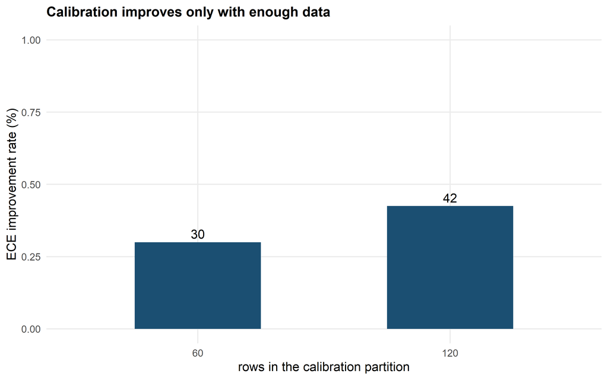

Figure 4: Calibration improvement depends on partition size: with 60 rows the improvement rate is low; with 120 it rises.

```r
ggplot(mc_tbl, aes(factor(calibration_n), improvement_rate)) +
  geom_col(fill = cores_smf[["primaria"]], width = .5) +
  geom_text(aes(label = fmt(100 * improvement_rate, 0)), vjust = -0.4) +
  labs(x = "rows in the calibration partition", y = "ECE improvement rate (%)",
       title = "Calibration improves only with enough data") +
  ylim(0, 1)
```

# 4 Thresholds: turning probability into decision

The 0.5 threshold is rarely the right one when classes are imbalanced and errors have different costs. `smf_optimize_threshold()` sweeps the grid and returns the best threshold for the chosen metric — with the full curve.

```r
best_f1 <- smf_optimize_threshold(disease$disease[i_te], p_te, metric = "f1",
                                  grid = seq(0.05, 0.95, by = 0.05),
                                  positive_label = "1")
tab_smf(best_f1$curve, caption = "Threshold sweep for F1 on the test partition.")
```

Threshold sweep for F1 on the test partition.

| threshold | value |
| --- | --- |
| 0.05 | 0.273 |
| 0.10 | 0.419 |
| 0.15 | 0.479 |
| 0.20 | 0.538 |
| 0.25 | 0.561 |
| 0.30 | 0.543 |
| 0.35 | 0.601 |
| 0.40 | 0.573 |
| 0.45 | 0.582 |
| 0.50 | 0.532 |
| 0.55 | 0.539 |
| 0.60 | 0.539 |
| 0.65 | 0.465 |
| 0.70 | 0.465 |
| 0.75 | 0.465 |
| 0.80 | 0.465 |
| 0.85 | 0.465 |
| 0.90 | 0.465 |
| 0.95 | 0.465 |

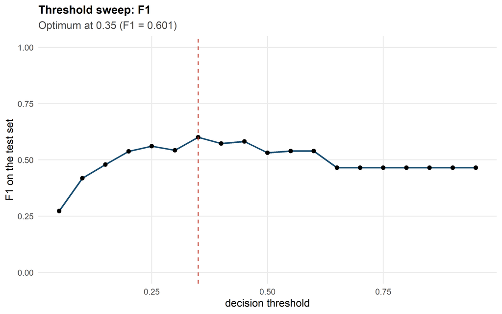

```r
ggplot(best_f1$curve, aes(threshold, value)) +
  geom_line(colour = cores_smf[["primaria"]], linewidth = .9) +
  geom_point(size = 1.8) +
  geom_vline(xintercept = best_f1$threshold, linetype = "dashed",
             colour = cores_smf[["alerta"]]) +
  labs(x = "decision threshold", y = "F1 on the test set",
       title = "Threshold sweep: F1",
       subtitle = paste0("Optimum at ", fmt(best_f1$threshold, 2),
                         " (F1 = ", fmt(best_f1$value, 3), ")")) +
  ylim(0, 1)
```

**TipIn your experiment**

Before choosing the threshold, write the **cost matrix**: how much does a false negative (undetected disease) cost against a false positive (unnecessary control)? With a 10:1 cost for false negatives, the optimal threshold falls even further than the F1 one. The package does not choose for you: it measures the curve so the decision is recorded, not improvised.

# 5 Part 4 exercises

**NoteExercise 4.1 — Search budget**

Run the random search with budgets 4, 8 and 16 and record the best inner RMSE and the selected configuration. Does the return justify the cost? Where would you stop?

**NoteExercise 4.2 — Missing objective**

Ask for `mae` as an objective in a specification that only declares `rmse` and read the message. Then fix the specification and repeat. Why is failing loudly better than returning an empty archive?

**NoteExercise 4.3 — Calibration with little data**

Repeat the calibration replicate with 30 rows. Does the improvement rate fall? What minimum number of calibration rows would you require before trusting the calibrator?

**NoteExercise 4.4 — Cost-based threshold**

Using the sensitivity curve from `smf_optimize_threshold()`, find the threshold that guarantees sensitivity >= 0.9. How many extra false positives does that cost relative to the 0.5 threshold?

**CautionSolutions**

**4.1.** The best inner RMSE improves little after ~8 evaluations in this small space; the marginal gain does not pay the cost. Budget is a design decision, not an algorithmic one.

**4.2.** The package aborts with `TUNING_OBJECTIVE_NOT_IN_METRICS`, listing the specification metrics. Failing loudly avoids the worst failure: an empty selection table that looks like a result.

**4.4.** With sensitivity >= 0.9 the threshold drops to the 0.10-0.15 range, sharply raising false positives. The pedagogical point is that **the threshold is a cost decision**, and it must come with the curve that supports it.